# Praca domowa 2

Szymon Kiełtyka

## Dane

Dane wykorzystane w Pracy domowej 2 opisują wycenę nieruchmości. Każda obserwacja jest pewną nieruchmością, która posiada informacje takie jak powierzchnia, liczba pokoi, liczba łazienek i wiele więcj. Opis wszystkich kolumn w pliku `README.md`.

## Zadanie 1

Jak wygląda rozkład ceny nieruchomości w poszczególnych kodach pocztowych na przestrzeni lat? Rozważamy kody pocztowe, które mają więcej niż 280 posiadłości.

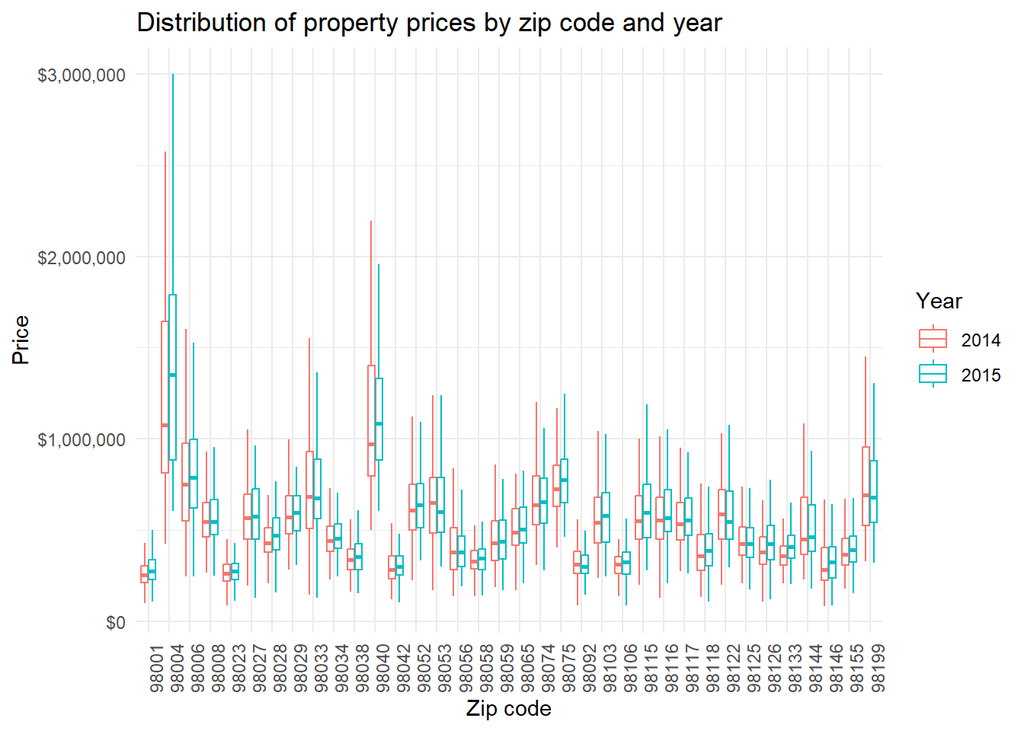

```r
df %>%
  left_join(
    df %>%
  group_by(zipcode) %>%
  summarise(house_count = n())
  ) %>%
  filter(house_count > 280) %>%
  mutate(year = format(date, "%Y")) %>%
  ggplot(aes(x = factor(zipcode), y = price, colour = year)) +
  geom_boxplot(outliers = FALSE) +
  labs(
    title = "Distribution of property prices by zip code and year",
    x = "Zip code",
    y = "Price",
    colour = "Year"
  ) +
  theme_minimal() +
  theme(axis.text.x = element_text(angle = 90)) +
  scale_y_continuous(labels = scales::dollar_format())
```

**Komentarz:**

Ogólnie w 2015 ceny wzrosły, jednak może się to różnić dla danego kodu pocztowego.

## Zadanie 2

Czy jest różnica w rozkładzie ceny nierchomości od powierzchni mieszkalnej uwzględniając podział na nieruchomości z piwnicą i bez?

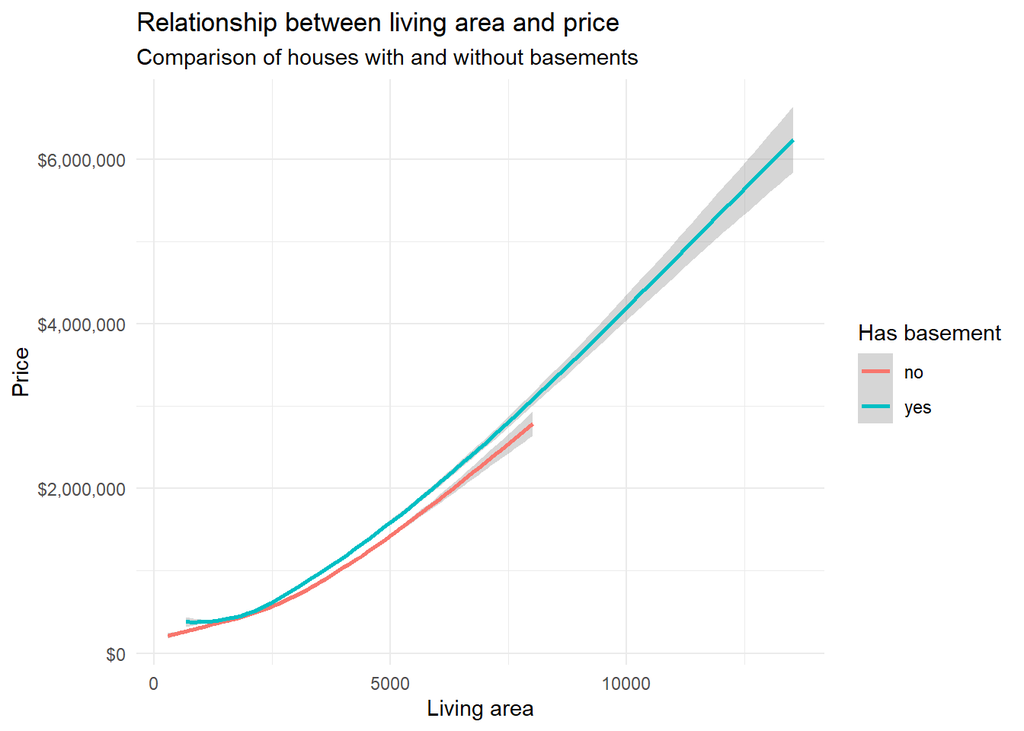

```r
df %>%
  mutate(is_basement = ifelse(sqft_basement > 0, "yes", "no")) %>%
  ggplot(aes(x = sqft_living, y = price, color = is_basement)) +
  geom_smooth(method = "loess") +
  scale_y_continuous(labels = scales::dollar_format()) +
  labs(
    title = "Relationship between living area and price",
    subtitle = "Comparison of houses with and without basements",
    x = "Living area",
    y = "Price",
    color = "Has basement"
  ) +
  theme_minimal()
```

**Komentarz:**

Róznica w cenach mieszkań bez piwnicy i z piwnicą jest dosyć mała, jednak mieszkania z piwnicą są droższe. Jest też o wiele więcej mieszkań o dużej powierzchni z piwnicą, niż mieszkań o dużej powierzchni bez pwinicy.

## Zadanie 3

Jaka jest zależność pomiędzy jakością wykończenia nieruchomości a liczbą pięter?

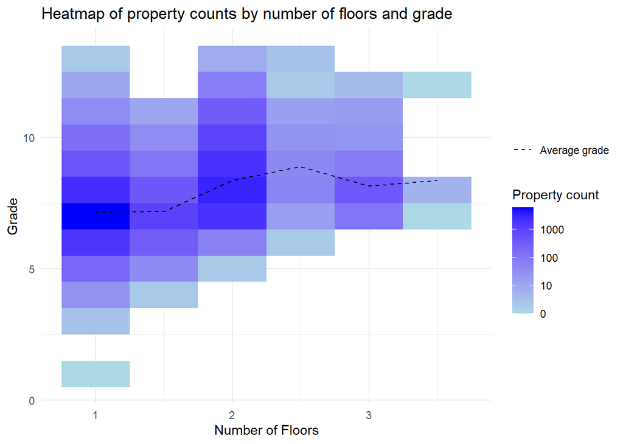

```r
df %>%
  group_by(floors, grade) %>%
  summarise(count = n()) %>%
  left_join(df %>%
             group_by(floors) %>%
             summarise(avg_grade = mean(grade))) %>%
  ggplot(aes(x = floors)) +
  geom_tile(aes(y = grade, fill = log10(count))) +
  scale_fill_gradient(low = "lightblue", high = "blue",
                      labels = c(0, 10, 100, 1000, 10000)) +
  geom_line(aes(y = avg_grade, linetype = "Average grade")) +
  labs(
    title = "Heatmap of property counts by number of floors and grade",
    x = "Number of Floors",
    y = "Grade",
    fill = "Property count",
    linetype = "Legend"
  ) +
  scale_linetype_manual(
    name = "",
    values = c("Average grade" = "dashed")
  ) +
  theme_minimal()
```

## Zadanie 4

Jaka jest zależność między powierzchnią mieszkalną nieruchomości a powierzchnią gruntu w podziale na liczbę sypialni?

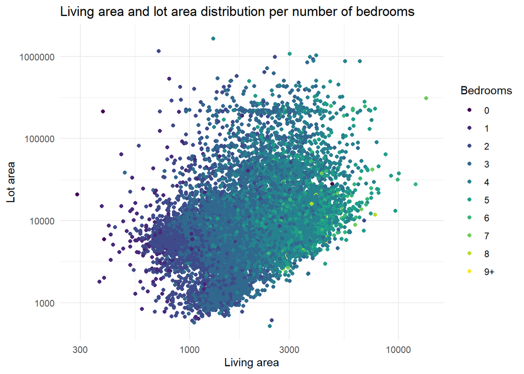

```r
df %>%
  mutate(bedrooms = ifelse(bedrooms >= 9, "9+", bedrooms)) %>%
  ggplot(aes(x = sqft_living, y = sqft_lot, color = factor(bedrooms))) +
  geom_point() +
  scale_y_log10(labels = ~ format(.x, scientific = FALSE)) +
  scale_x_log10() +
  scale_color_viridis_d() +
  labs(
    title = "Living area and lot area distribution per number of bedrooms",
    x = "Living area",
    y = "Lot area",
    color = "Bedrooms"
  ) +
  theme_minimal()
```

**Komentarz:**

Powierzchnia mieszkalna rośnie wraz z liczbą sypialni. Powierzchnia gruntu również rośnie wraz z liczbą sypialni, jednak są nieruchomości, które mają dużą powierzchnie gruntu, a małą liczbę sypialni.

## Zadanie 5

Rozważmy tylko nieruchomości, które miały remont. W której dekadzie było najwięcej przeprowadzonych remontów? Czy w poszczególnych dekadach jest porównywalny procent nieruchmości dla każdej wartości miary jakości i wykończenia nieruchomości?

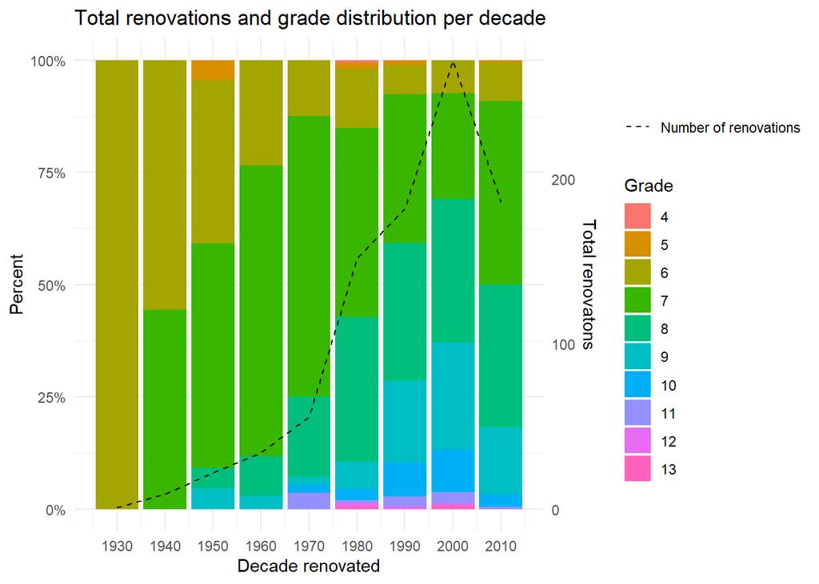

```r
df %>%
  filter(yr_renovated > 0) %>%
  mutate(decade_renovated = floor(yr_renovated / 10) * 10) %>%
  inner_join(df %>%
             filter(yr_renovated > 0) %>%
             mutate(decade_renovated = floor(yr_renovated / 10) * 10) %>%
             group_by(decade_renovated) %>%
             mutate(total_count = n())) %>%
  ggplot(aes(x = decade_renovated)) +
  geom_bar(aes(fill = as.factor(grade)), position = "fill") +
  geom_line(aes(y = total_count * (1/272), linetype = "Number of renovations")) +
  scale_y_continuous(
    name = "Percent",
    labels = scales::percent_format(),
    sec.axis = sec_axis(~ . / (1/272), name = "Total renovatons")
  ) +
  labs(
    x = "Decade renovated",
    fill = "Grade",
    title = "Total renovations and grade distribution per decade"
  ) +
  scale_linetype_manual(
    name = "",
    values = c("Number of renovations" = "dashed")
  ) +
  scale_x_continuous(breaks = seq(1900, 2020, 10)) +
  theme_minimal()
```

**Komentarz:**

Najwięcej renowacjii było w latach 2000 remontów (było ich 272). Procent nieruchmości dla każdej wartości miary jakości i wykończenia nieruchomości zmienia się w ciągu dekad. Procent nieruchomości z wyższymi ocenami rośnie z dekady na dekadę, aż do lat 2010, gdzie ten procent spadł.

## Zadanie 6

Jak prezentuje się wartość minimalna, średnia i maksymalna ceny nieruchmości w podziele na rok budowy nieruchomości.

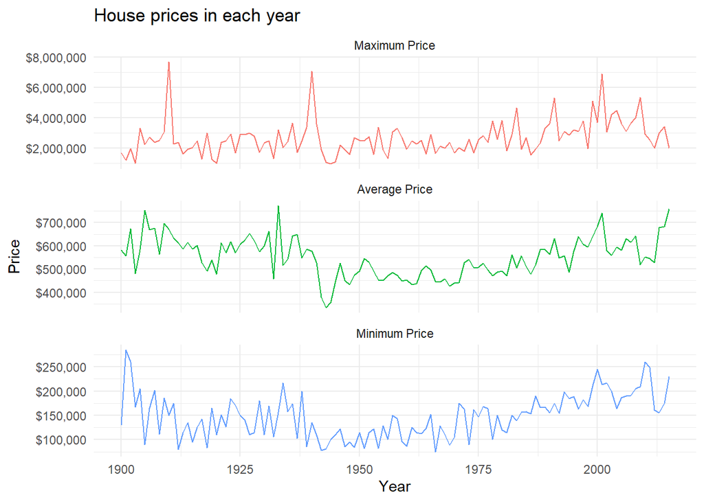

```r
df %>%
  mutate(year = format(date, "%Y")) %>%
  group_by(yr_built) %>%
  summarise(
    min_price = min(price),
    mean_price = mean(price),
    max_price = max(price)
  ) %>%
  pivot_longer(cols = c(min_price, mean_price, max_price), names_to = "price_type", values_to = "price") %>%
  ggplot(aes(x = yr_built, y = price, color = price_type)) +
  geom_line() +
  facet_wrap(~price_type, scales = "free_y", ncol = 1, labeller = as_labeller(c(
    min_price = "Minimum Price",
    mean_price = "Average Price",
    max_price = "Maximum Price"
  ))) +
  labs(x = "Year", y = "Price", title = "House prices in each year") +
  theme_minimal() +
  theme(legend.position = "none") +
  scale_y_continuous(labels = scales::dollar_format())
```

**Komentarz:**

Cena maksymalna jest bardzo zróżnicowana, z roku na rok mogą być bardzo duże skoki. Cena średnia była większa przed rokiem 1940 i po roku 1975, niż w latach 1940-1975, jednak nie są to duże zmiany. Cena minimalna na przestrzeni lat jest bardzo podobna, zazwyczaj zmiany nie są większe niż $100 000.